# HW8

# ANOVA and Graphing

```r
sim_aov2<-aov(Ratio~Species,data=simcolony2)
summary(sim_aov2)
```

```
##              Df  Sum Sq  Mean Sq F value  Pr(>F)
## Species       2 0.01174 0.005869   5.793 0.00365 **
## Residuals   179 0.18135 0.001013
## ---
## Signif. codes:  0 '***' 0.001 '**' 0.01 '*' 0.05 '.' 0.1 ' ' 1
```

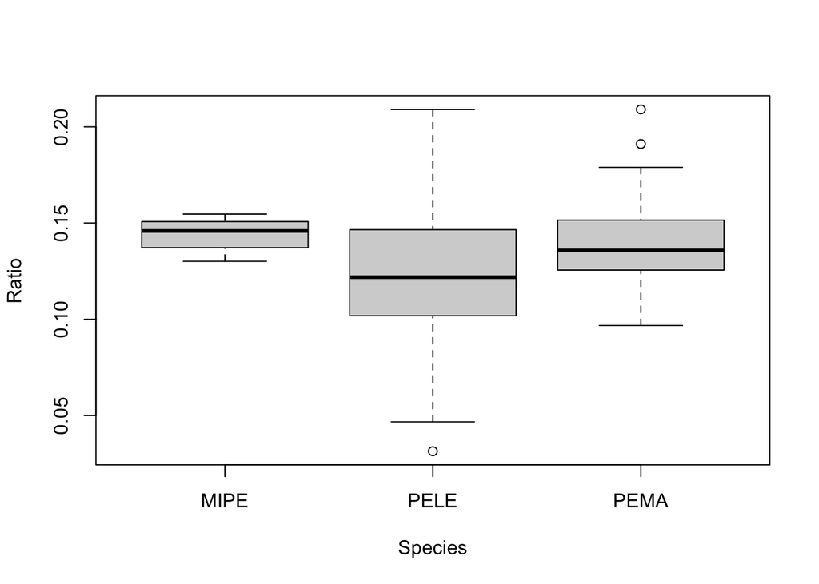

```r
boxplot(data=simcolony2,Ratio~Species)
```

## Changing Sample Size

```r
PELE3<-data.frame("PELE",rnorm(40,0.124,0.036))
colnames(PELE3)<-c("Species","Ratio")
MIPE3<-data.frame("MIPE",rnorm(40,0.141,0.012))
colnames(MIPE3)<-c("Species","Ratio")
PEMA3<-data.frame("PEMA",rnorm(40,0.138,0.025))
colnames(PEMA3)<-c("Species","Ratio")
simcolony3<-rbind(PEMA3,PELE3,MIPE3)
```

# ANOVA and Graphing

```r
sim_aov3<-aov(Ratio~Species,data=simcolony3)
summary(sim_aov3)
```

```
##              Df  Sum Sq  Mean Sq F value  Pr(>F)
## Species       2 0.00606 0.003030   4.879 0.00922 **
## Residuals   117 0.07265 0.000621
## ---
## Signif. codes:  0 '***' 0.001 '**' 0.01 '*' 0.05 '.' 0.1 ' ' 1
```

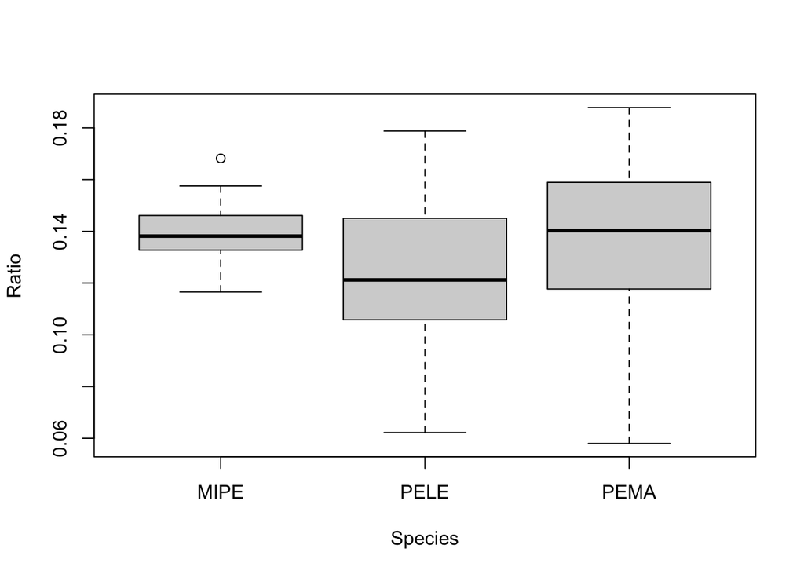

```r
boxplot(data=simcolony3,Ratio~Species)
```

I dropped all three sample sizes to the smallest sample size of 5, where the analysis was not significant. I then kept raising the sizes evenly which lowered the p-value of the anova. When I reached a sample size of 40 I found that the anova produced a significant result most of the time. I still however recieved the occasional randomized result that was not significant. This makes sense that as I have larger sample sizes and they trend closer toward the mean that my anova would be significant on more of the random samples.